# Class 3

January 19, 2025

# 3 Visualization 2

In this lecture, we will lift our `ggplot2` skills to the next level!

## 3.1 Learning objectives

- Deciding what plot is appropriate for what kind of data.
- Customizing plots: Take a sad plot and make it better.
- Saving plots.
- Making figure panels.
- Debugging.
- Making animations.
- Defining snippets.

## 3.2 Install and load packages, load data, set theme

Let’s first install the new packages that you might not have yet.

```r
install.packages(c("gganimate", "gapminder", "ggridges", "devtools", "png", "gifski", "patchwork", "ggforce", "ggstats"))
```

Now, let’s load the packages that we need for this chapter.

```r
library("knitr")     # for rendering the RMarkdown file
library("patchwork") # for making figure panels
library("ggridges")  # for making joyplots
library("gganimate") # for making animations
library("gapminder") # data available from Gapminder.org
library("tidyverse") # for plotting (and many more cool things we'll discover later)
library("ggforce")   # for sina plots
library("ggstats")   # for bar plots and their labels
```

And set some settings:

```r
# these options here change the formatting of how comments are rendered
opts_chunk$set(comment = "",
               fig.show = "hold")

# this just suppresses an unnecessary message about grouping
options(dplyr.summarise.inform = F)

# set the default plotting theme
theme_set(theme_classic() + #set the theme
            theme(text = element_text(size = 20))) #set the default text size
```

And let’s load the diamonds data again. (using `<-` rather than `=` – but let’s talk about that)

```r
df.diamonds <- diamonds
```

## 3.3 Overview of different plot types for different things

Different plots work best for different kinds of data. Let’s take a look at some.

### 3.3.1 Proportions

#### 3.3.1.1 Stacked bar charts

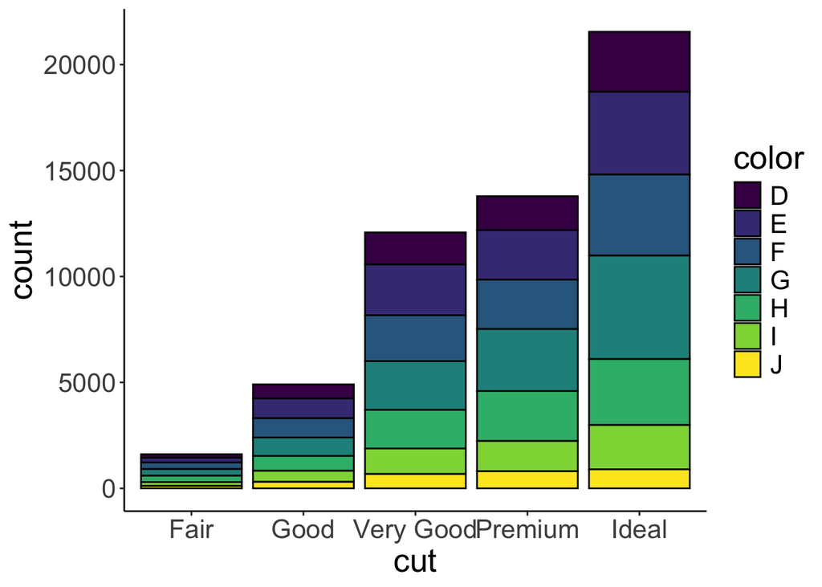

```r
ggplot(data = df.diamonds,
       mapping = aes(x = cut,
                     fill = color)) +
  geom_bar(color = "black")
```

This bar chart shows for the different cuts (x-axis), the number of diamonds of different color. Stacked bar charts give a good general impression of the data. However, it’s difficult to precisely compare different proportions.

#### 3.3.1.2 Pie charts

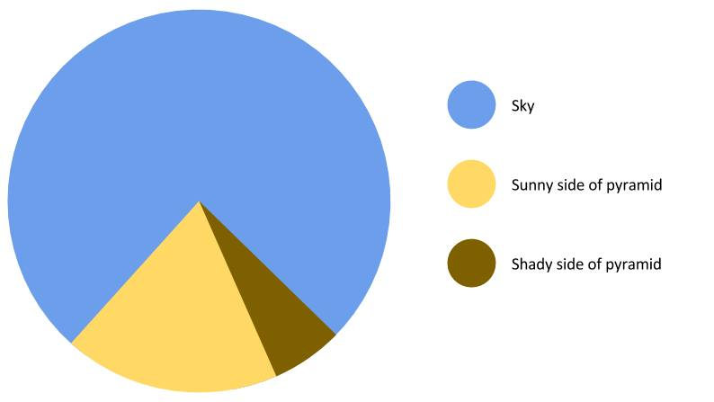

Figure 3.1: Finally a pie chart that makes sense.

Pie charts have a bad reputation. And there are indeed a number of problems with pie charts:

- proportions are difficult to compare
- don’t look good when there are many categories

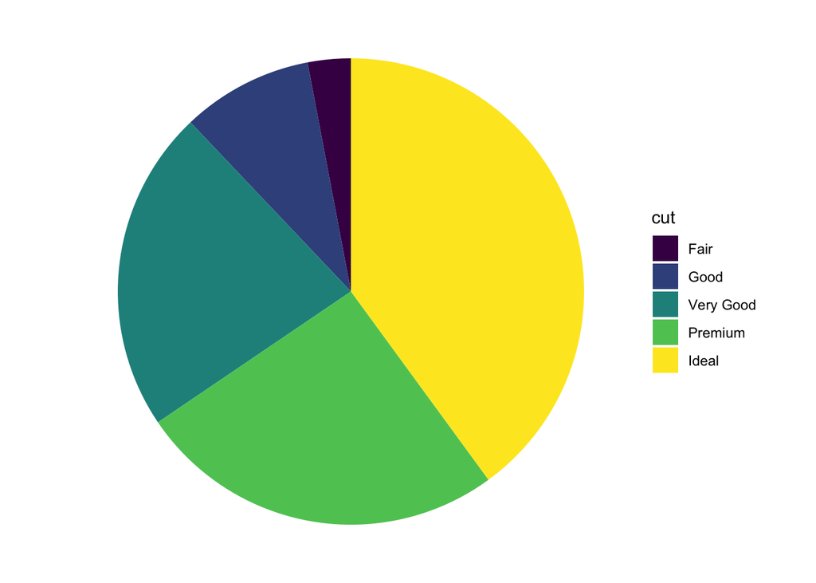

```r
ggplot(data = df.diamonds,
       mapping = aes(x = 1,
                     fill = cut)) +
  geom_bar() +
  coord_polar("y", start = 0) +
  theme_void()
```

We can create a pie chart with `ggplot2` by changing the coordinate system using `coord_polar()`.

There are two things to learn from the use of `coord_polar()` here:

1. Changing the coordinate system is something you can do in ggplot and will sometimes have to do.
2. It’s a pretty awkward way to make a pie chart–which helps teach the lesson of YOU SHOULD AVOID PIE CHARTS!

If we are interested in comparing proportions and we don’t have too many data points, then tables are a good alternative to showing figures.

### 3.3.2 Comparisons

Often we want to compare the data from many different conditions. And sometimes, it’s also useful to get a sense for what the individual participant data look like. Here is a plot that achieves both.

#### 3.3.2.1 Means and individual data points

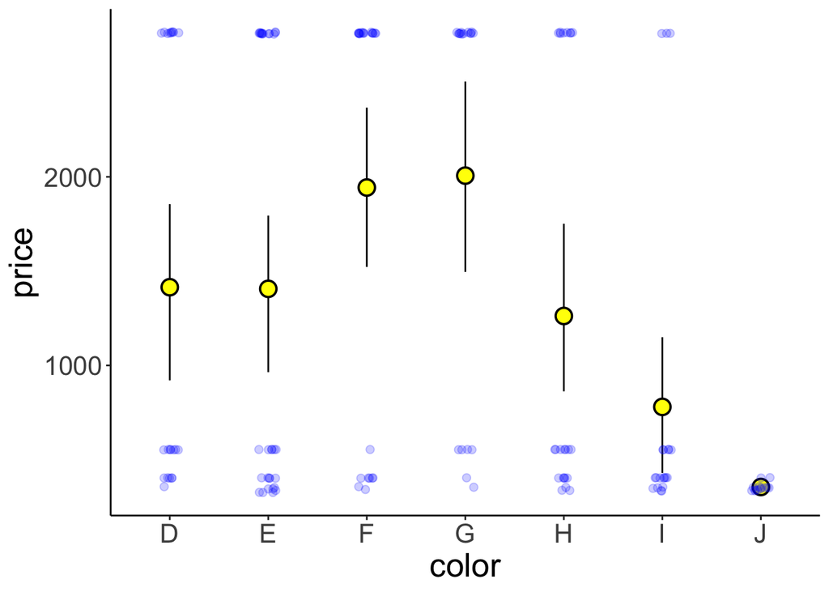

```r
ggplot(data = df.diamonds[1:150, ],
       mapping = aes(x = color,
                     y = price)) +
  # means with confidence intervals
  stat_summary(fun.data = "mean_cl_boot",
               geom = "pointrange",
               color = "black",
               fill = "yellow",
               shape = 21,
               size = 1) +
  # individual data points (jittered horizontally)
  geom_point(alpha = 0.2,
             color = "blue",
             position = position_jitter(width = 0.1,
                                        height = 0),
             size = 2)
```

Note that I’m only plotting the first 150 entries of the data here by setting `data = df.diamonds[1:150,]` in `gpplot()`.

This plot shows means, bootstrapped confidence intervals, and individual data points. I’ve used two tricks to make the individual data points easier to see. 1. I’ve set the `alpha` attribute to make the points somewhat transparent. 2. I’ve used the `position_jitter()` function to jitter the points horizontally. 3. I’ve used `shape = 21` for displaying the mean. For this circle shape, we can set a `color` and `fill` (see Figure 3.3)

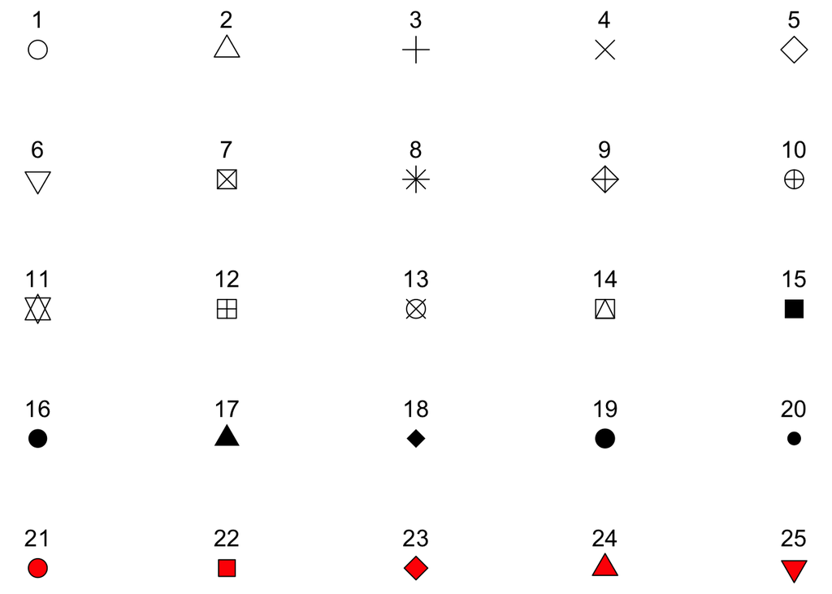

Figure 3.3: Different shapes that can be used for plotting.

Here is an example of an actual plot that I’ve made for a paper that I’m working on (using the same techniques).

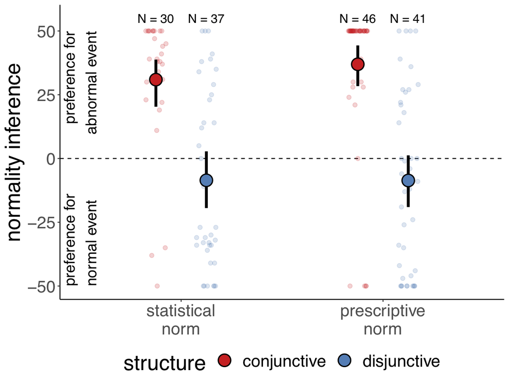

Figure 3.4: Participants’ preference for the conjunctive (top) versus dis-junctive (bottom) structure as a function of the explanation (abnormal cause vs. normalcause) and the type of norm (statistical vs. prescriptive). Note: Large circles are groupmeans. Error bars are bootstrapped 95% confidence intervals. Small circles are individualparticipants’ judgments (jittered along the x-axis for visibility)

#### 3.3.2.2 Boxplots

Another way to get a sense for the distribution of the data is to use box plots.

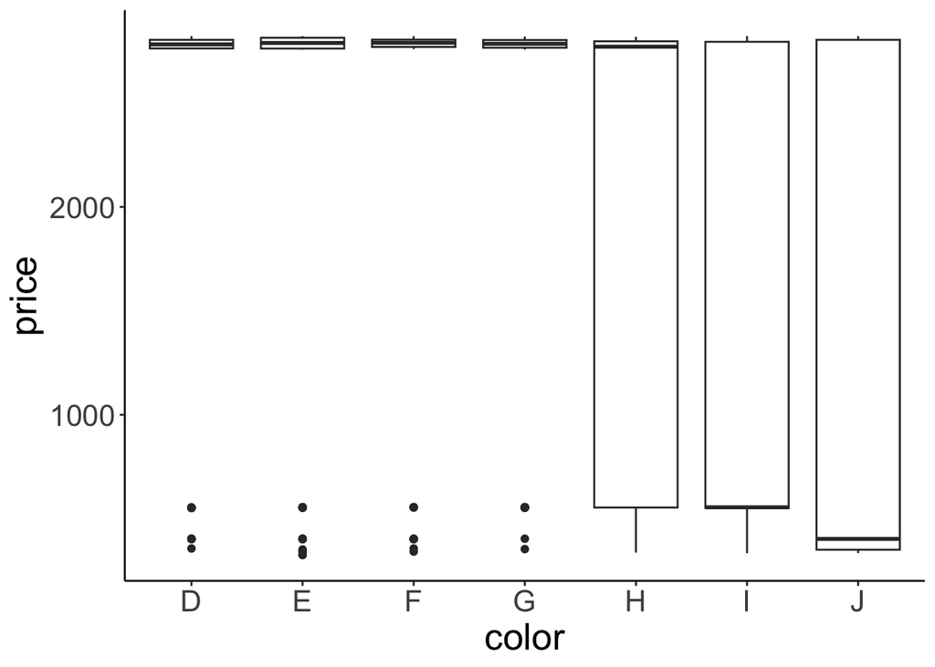

```r
ggplot(data = df.diamonds[1:500,],
       mapping = aes(x = color,
                     y = price)) +
  geom_boxplot()
```

What do boxplots show? Here adapted from `help(geom_boxplot())`:

> The boxplots show the median as a horizontal black line. The lower and upper hinges correspond to the first and third quartiles (the 25th and 75th percentiles) of the data. The whiskers (= black vertical lines) extend from the top or bottom of the hinge by at most 1.5 * IQR (where IQR is the inter-quartile range, or distance between the first and third quartiles). Data beyond the end of the whiskers are called “outlying” points and are plotted individually.

Boxplots are useful, but they’re not flawless. Many data sets are consistent with the same boxplot.

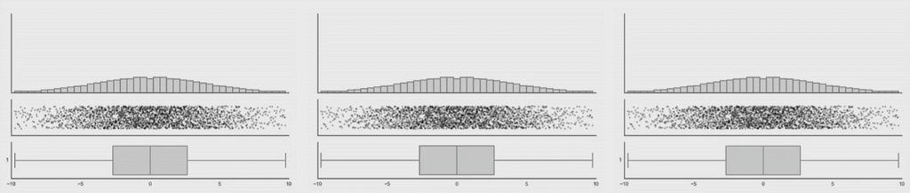

Figure 3.5: Box plot distributions. Source: https://www.autodeskresearch.com/publications/samestats

Figure 3.5 shows three different distributions that each correspond to the same boxplot.

If you do have a lot of data points, then violin plots can be helpful – and you can still superimpose boxplots on the violin plots.

If there is not too much data, you can plot jitterred individual data points instead (jitterred to avoid overplotting). Even better, you can use sina plots, which jitter the data to the width that the violin plot would be.

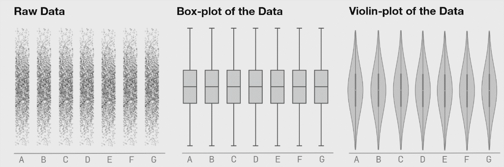

Figure 3.6: Boxplot distributions. Source: https://www.autodeskresearch.com/publications/samestats

Figure 3.6 shows the same raw data represented as jittered dots, boxplots, and violin plots.

#### 3.3.2.3 Violin plots

We make violin plots like so:

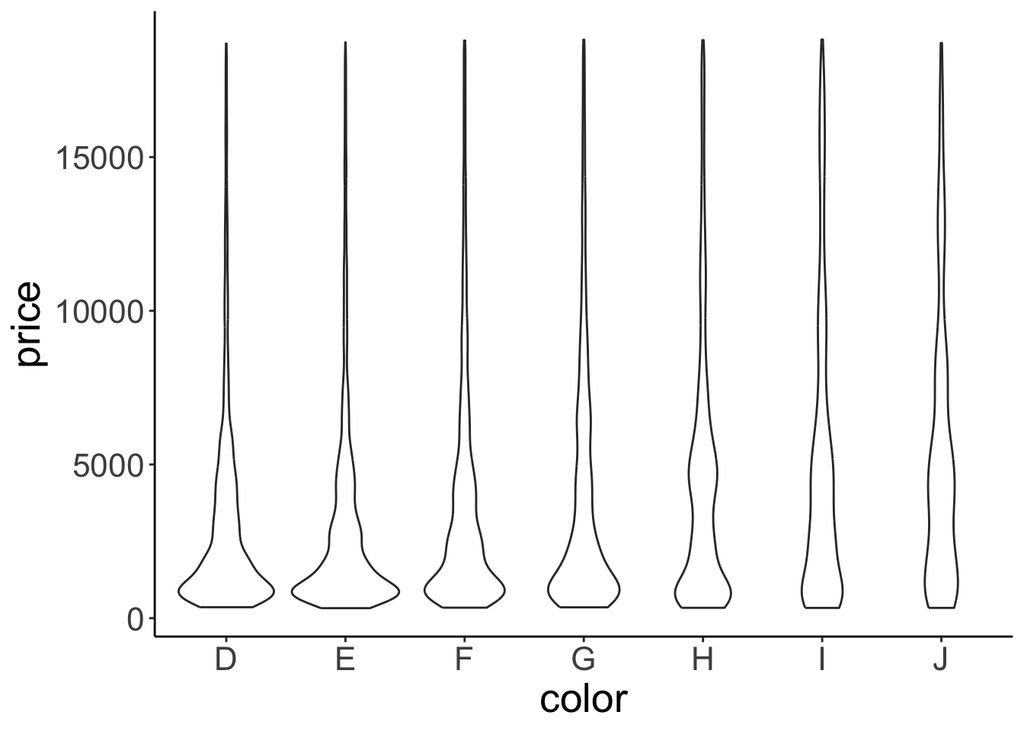

```r
ggplot(data = df.diamonds,
       mapping = aes(x = color,
                     y = price)) +
  geom_violin()
```

Violin plots are good for detecting bimodal distributions. They work well when:

1. You have many data points.
2. The data is continuous.

Here’s how to add boxplots over a violin plot:

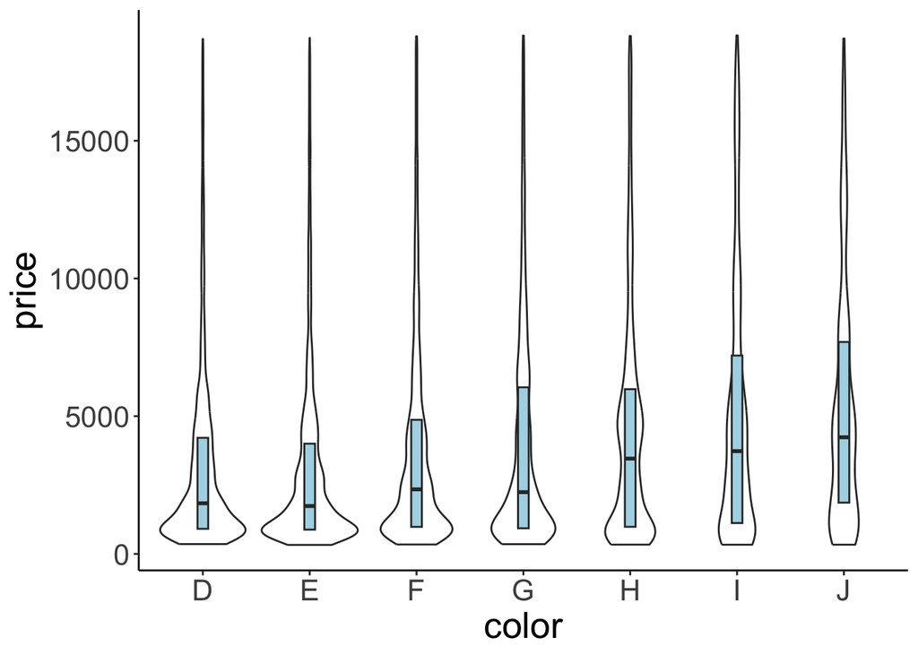

```r
ggplot(data = df.diamonds,
       mapping = aes(x = color,
                     y = price)) +
  geom_violin() +
  geom_boxplot(width=.1, outlier.shape=NA, coef=0, fill='lightblue')
```

(You can find the advice about `outlier.shape=NA` and `coef=0` by googling *geom_boxplot no whiskers*, which sends you to https://stackoverflow.com/questions/18459287/remove-whiskers-in-box-whisker-plot)

It’s important to draw the boxplot *after* the violin plot, because otherwise the violin plot will be drawn on top of it and hide it:

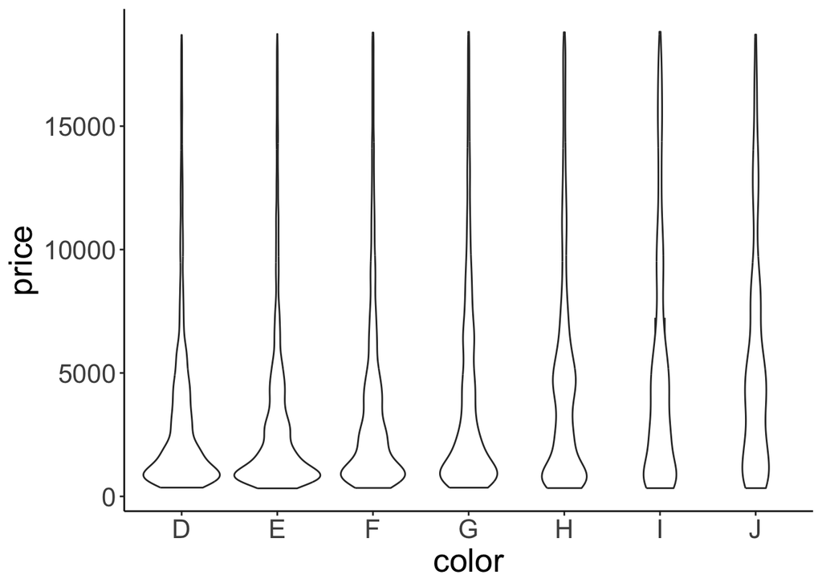

```r
ggplot(data = df.diamonds,
       mapping = aes(x = color,
                     y = price)) +
  geom_boxplot(width=.1, outlier.shape=NA, coef=0, fill='lightblue') +
  geom_violin()
```

Violin plots don’t work well for Likert-scale data (e.g. ratings on a discrete scale from 1 to 7). Here is a simple example:

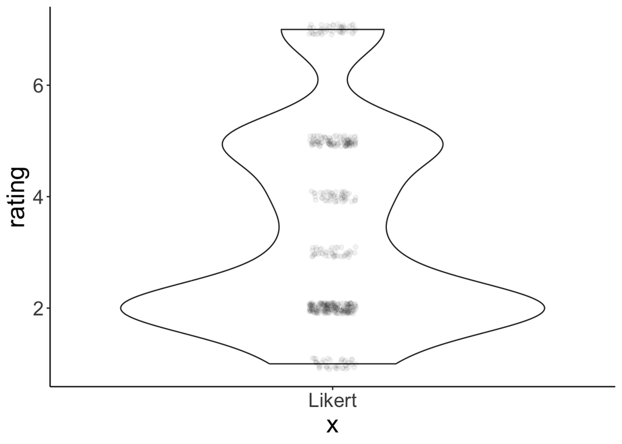

```r
set.seed(1)
data = tibble(rating = sample(x = 1:7,
                              prob = c(0.1, 0.4, 0.1, 0.1, 0.2, 0, 0.1),
                              size = 500,
                              replace = T))

ggplot(data = data,
       mapping = aes(x = "Likert",
                     y = rating)) +
  geom_violin() +
  geom_point(position = position_jitter(width = 0.05,
                                        height = 0.1),
             alpha = 0.05)
```

This represents a vase much better than it represents the data.

#### 3.3.2.4 Sina plots

The df.diamonds dataset is large (`df.diamonds |> count()` rows!) so plotting individual data points, as in sina plot (from the `ggforce` package) would be silly. But let’s take less than 1% of the dataset just to illustrate how a sina plot would work:

```r
df.diamonds |> count()
```

```
# A tibble: 1 × 1
      n
  <int>
1 53940
```

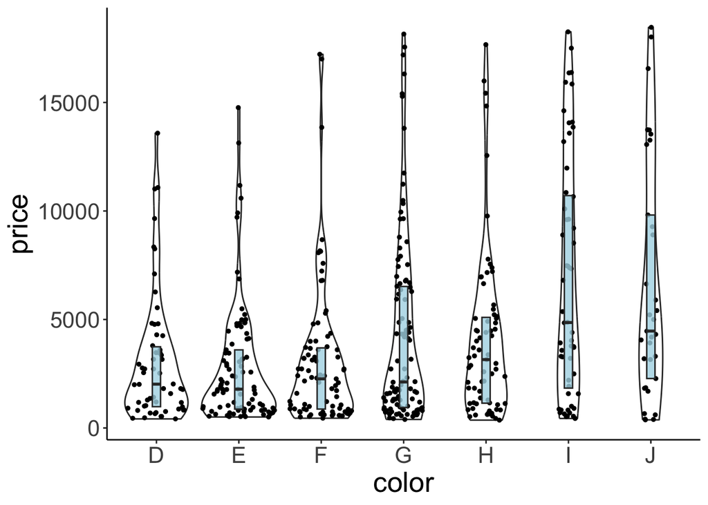

```r
ggplot(data = df.diamonds |> sample_n(500),
       mapping = aes(x = color,
                     y = price)) +
  geom_violin() +
  geom_sina(size=1) +
  geom_boxplot(width=.1, outlier.shape=NA, coef=0, fill='lightblue', alpha=.8)
```

Using the sina plot exposes the details of the dataset and the ‘big picture’ of a dataset at the same time.

#### 3.3.2.5 Joy plots

We can also show the distributions along the x-axis using the `geom_density_ridges()` function from the `ggridges` package.

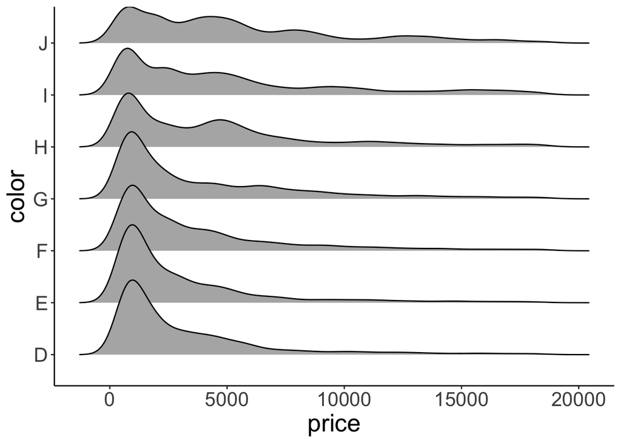

```r
ggplot(data = df.diamonds,
       mapping = aes(x = price,
                     y = color)) +
  ggridges::geom_density_ridges(scale = 1.5)
```

#### 3.3.2.6 Practice plot 1

Try to make the plot shown in Figure 3.7. Here is a tip:

- For the data argument in `ggplot()` use: `df.diamonds[1:10000, ]` (this selects the first 10000 rows).

```r
# write your code here
```

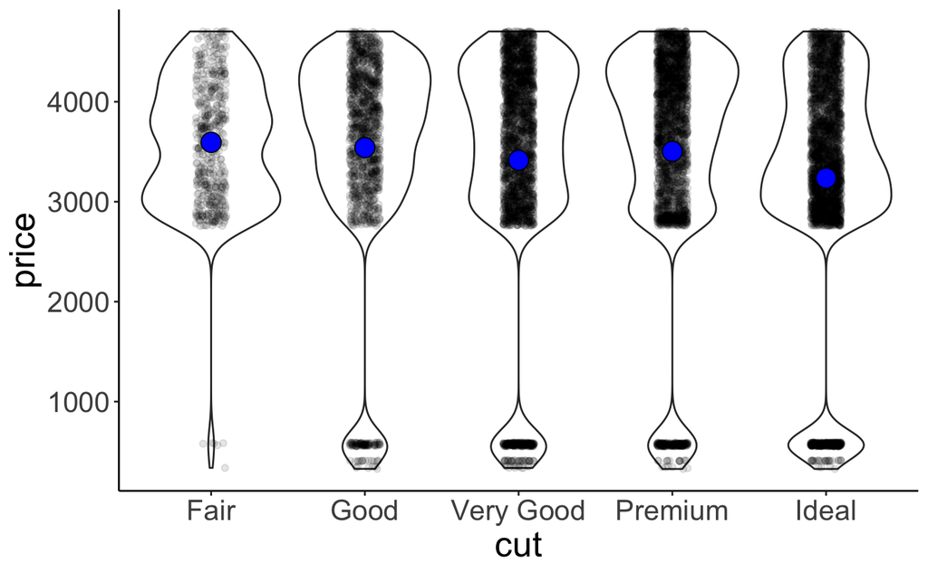

Figure 3.7: Practice plot 1.

### 3.3.3 Relationships

#### 3.3.3.1 Scatter plots

Scatter plots are great for looking at the relationship between two continuous variables.

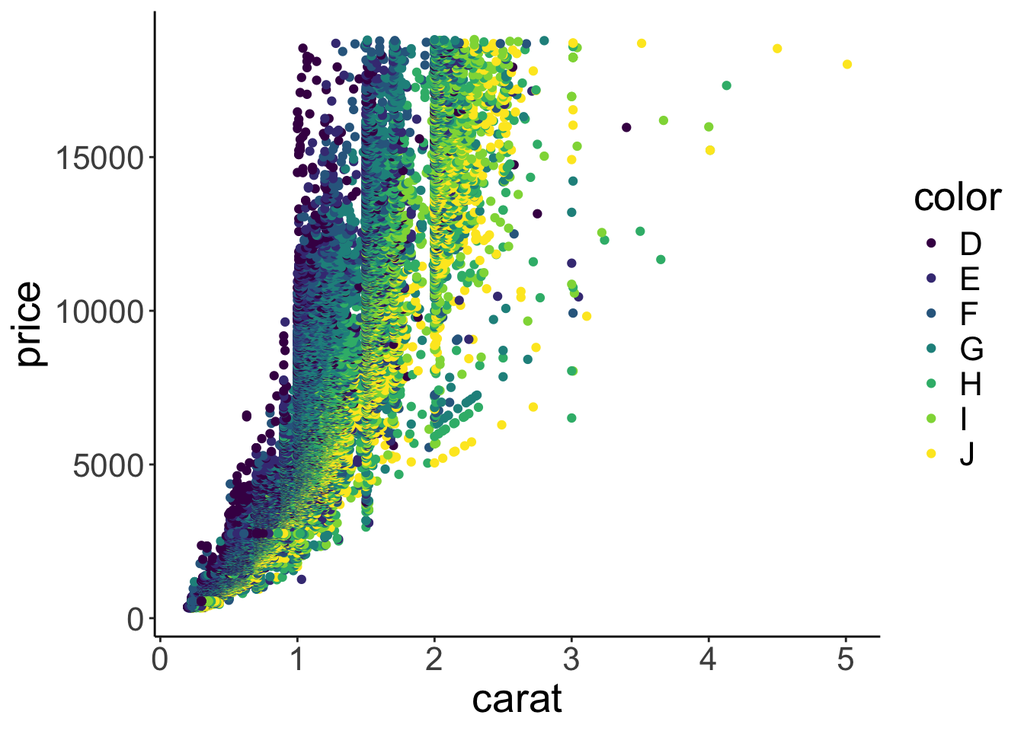

```r
ggplot(data = df.diamonds,
       mapping = aes(x = carat,
                     y = price,
                     color = color)) +
  geom_point()
```

#### 3.3.3.2 Raster plots

These are useful for looking how a variable of interest varies as a function of two other variables. For example, when we are trying to fit a model with two parameters, we might be interested to see how well the model does for different combinations of these two parameters. Here, we’ll plot what `carat` values diamonds of different `color` and `clarity` have.

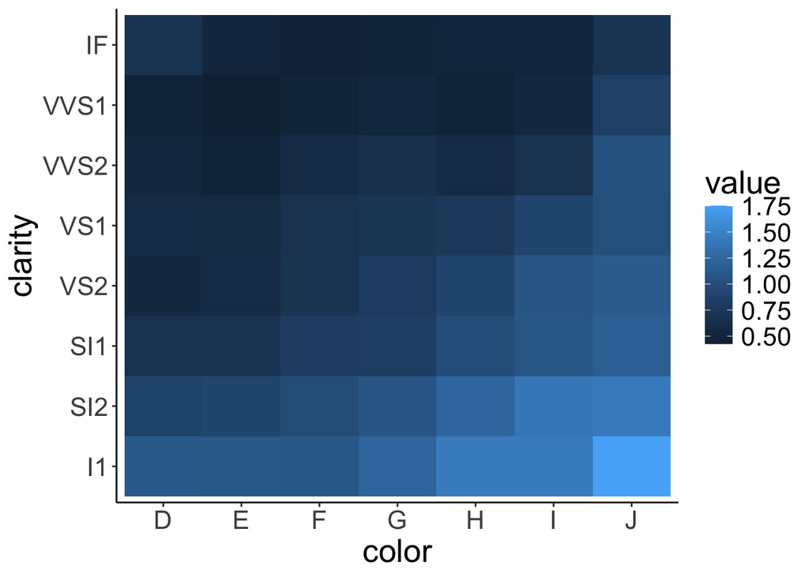

```r
ggplot(data = df.diamonds,
       mapping = aes(x = color,
                     y = clarity,
                     z = carat)) +
  stat_summary_2d(fun = "mean",
                  geom = "tile")
```

Not too bad. Let’s add a few tweaks to make it look nicer.

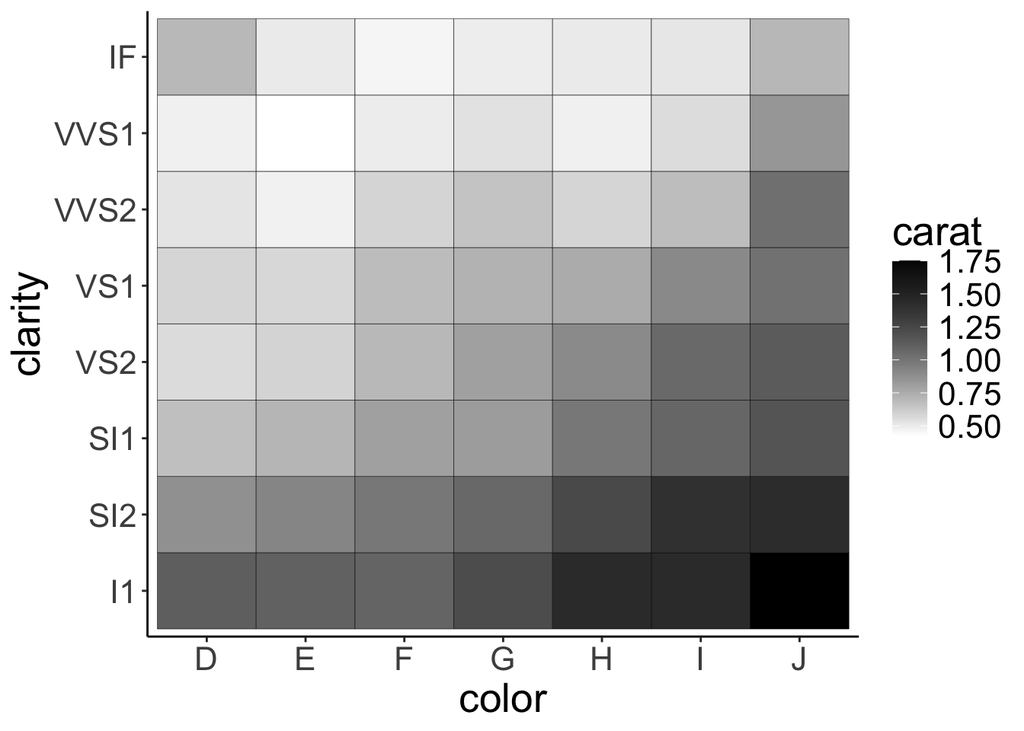

```r
ggplot(data = df.diamonds,
       mapping = aes(x = color,
                     y = clarity,
                     z = carat)) +
  stat_summary_2d(fun = "mean",
                  geom = "tile",
                  color = "black") +
  scale_fill_gradient(low = "white",
                      high = "black") +
  labs(fill = "carat")
```

### 3.3.4 Temporal data

Line plots are a good choice for temporal data. Here, I’ll use the `txhousing` data that comes with the `ggplot2` package. The dataset contains information about housing sales in Texas.

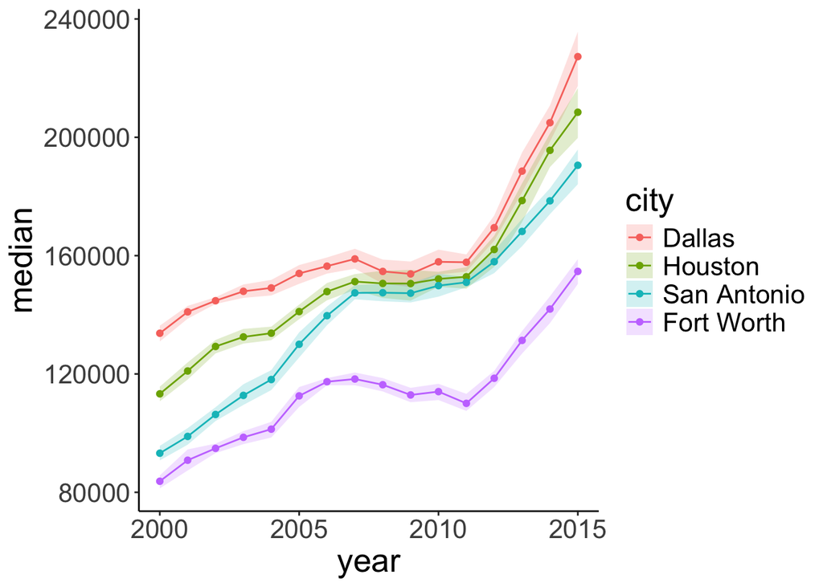

```r
# ignore this part for now (we'll learn about data wrangling soon)
df.plot = txhousing %>%
  filter(city %in% c("Dallas", "Fort Worth", "San Antonio", "Houston")) %>%
  mutate(city = factor(city, levels = c("Dallas", "Houston", "San Antonio", "Fort Worth")))

ggplot(data = df.plot,
       mapping = aes(x = year,
                     y = median,
                     color = city,
                     fill = city)) +
  stat_summary(fun.data = "mean_cl_boot",
               geom = "ribbon",
               alpha = 0.2,
               linetype = 0) +
  stat_summary(fun = "mean", geom = "line") +
  stat_summary(fun = "mean", geom = "point")
```

Ignore the top part where I’m defining `df.plot` for now (we’ll look into this in the next class). The other part is fairly straightforward. I’ve used `stat_summary()` three times: First, to define the confidence interval as a `geom = "ribbon"`. Second, to show the lines connecting the means, and third to put the means as data points points on top of the lines.

Let’s tweak the figure some more to make it look real good.

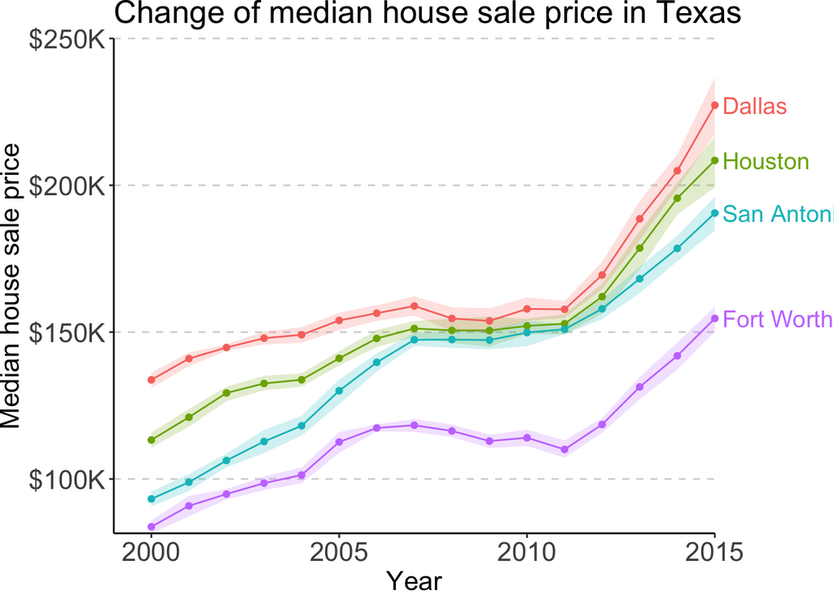

```r
df.plot = txhousing %>%
  filter(city %in% c("Dallas", "Fort Worth", "San Antonio", "Houston")) %>%
  mutate(city = factor(city, levels = c("Dallas", "Houston", "San Antonio", "Fort Worth")))

df.text = df.plot %>%
  filter(year == max(year)) %>%
  group_by(city) %>%
  summarize(year = mean(year) + 0.2,
            median = mean(median))

ggplot(data = df.plot,
       mapping = aes(x = year,
                     y = median,
                     color = city,
                     fill = city)) +
  # draw dashed horizontal lines in the background
  geom_hline(yintercept = seq(from = 100000,
                              to = 250000,
                              by = 50000),
             linetype = 2,
             alpha = 0.2) +
  # draw ribbon
  stat_summary(fun.data = mean_cl_boot,
               geom = "ribbon",
               alpha = 0.2,
               linetype = 0) +
  # draw lines connecting the means
  stat_summary(fun = "mean", geom = "line") +
  # draw means as points
  stat_summary(fun = "mean", geom = "point") +
  # add the city names
  geom_text(data = df.text,
            mapping = aes(label = city),
            hjust = 0,
            size = 5) +
  # set the limits for the coordinates
  coord_cartesian(xlim = c(1999, 2015),
                  clip = "off",
                  expand = F) +
  # set the x-axis labels
  scale_x_continuous(breaks = seq(from = 2000,
                                  to = 2015,
                                  by = 5)) +
  # set the y-axis labels
  scale_y_continuous(breaks = seq(from = 100000,
                                  to = 250000,
                                  by = 50000),
                     labels = str_c("$",
                                    seq(from = 100,
                                        to = 250,
                                        by = 50),
                                    "K")) +
  # set the plot title and axes titles
  labs(title = "Change of median house sale price in Texas",
       x = "Year",
       y = "Median house sale price") +
  theme(title = element_text(size = 16),
        legend.position = "none",
        plot.margin = margin(r = 1, unit = "in"))
```

## 3.4 Customizing plots

So far, we’ve seen a number of different ways of plotting data. Now, let’s look into how to customize the plots. For example, we may want to change the axis labels, add a title, increase the font size. `ggplot2` let’s you customize almost anything.

Let’s start simple.

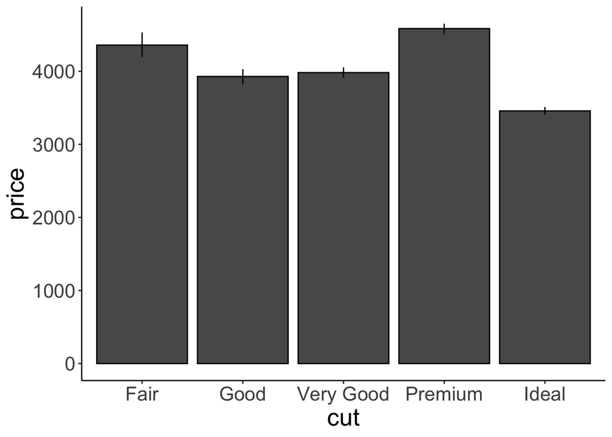

```r
ggplot(data = df.diamonds,
       mapping = aes(x = cut, y = price)) +
  stat_summary(fun = "mean",
               geom = "bar",
               color = "black") +
  stat_summary(fun.data = "mean_cl_boot",
               geom = "linerange")
```

This plot shows the average price for diamonds with a different quality of the cut, as well as the bootstrapped confidence intervals. Here are some things we can do to make it look nicer.

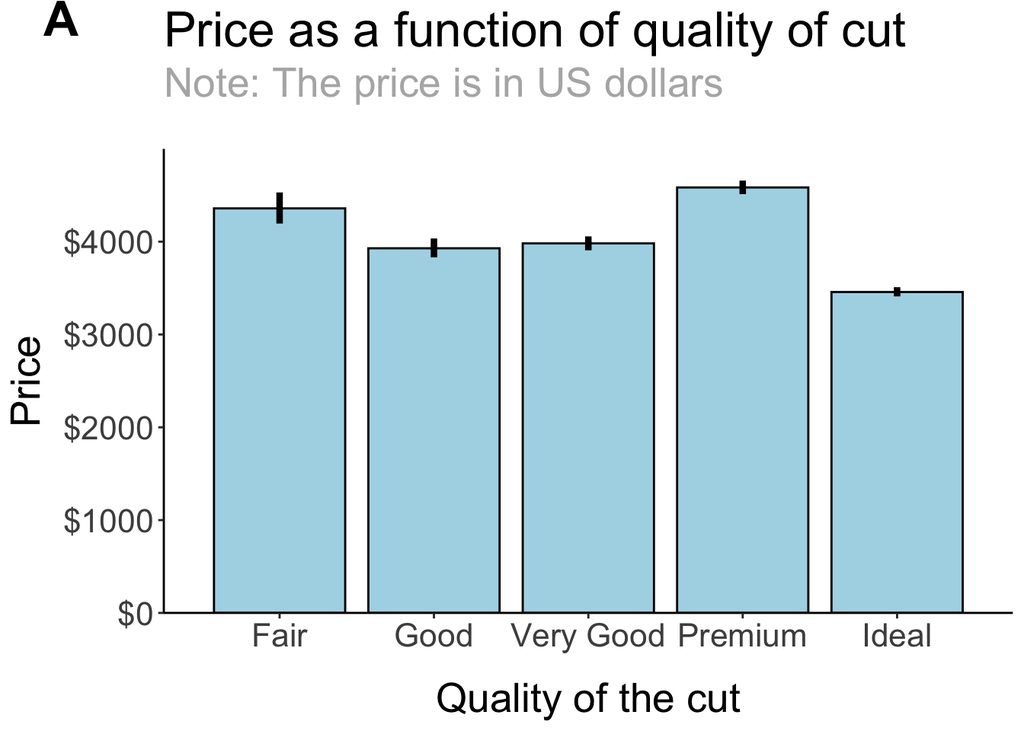

```r
ggplot(data = df.diamonds,
       mapping = aes(x = cut,
                     y = price)) +
  # change color of the fill, make a little more space between bars by setting their width
  stat_summary(fun = "mean",
               geom = "bar",
               color = "black",
               fill = "lightblue",
               width = 0.85) +
  # make error bars thicker
  stat_summary(fun.data = "mean_cl_boot",
               geom = "linerange",
               linewidth = 1.5) +
  # adjust what to show on the y-axis
  scale_y_continuous(breaks = seq(from = 0, to = 4000, by = 1000),
                     labels = str_c("$", seq(from = 0, to = 4000, by = 1000))) +
  # adjust the range of both axes
  coord_cartesian(xlim = c(0.25, 5.75),
                  ylim = c(0, 5000),
                  expand = F) +
  # add a title, subtitle, and changed axis labels
  labs(title = "Price as a function of quality of cut",
       subtitle = "Note: The price is in US dollars",
       tag = "A",
       x = "Quality of the cut",
       y = "Price") +
  theme(
    # adjust the text size
    text = element_text(size = 20),
    # add some space at top of x-title
    axis.title.x = element_text(margin = margin(t = 0.2, unit = "inch")),
    # add some space t the right of y-title
    axis.title.y = element_text(margin = margin(r = 0.1, unit = "inch")),
    # add some space underneath the subtitle and make it gray
    plot.subtitle = element_text(margin = margin(b = 0.3, unit = "inch"),
                                 color = "gray70"),
    # make the plot tag bold
    plot.tag = element_text(face = "bold"),
    # move the plot tag a little
    plot.tag.position = c(0.05, 0.99)
  )
```

I’ve tweaked quite a few things here (and I’ve added comments to explain what’s happening). Take a quick look at the `theme()` function to see all the things you can change.

### 3.4.1 Anatomy of a `ggplot`

I suggest to use this general skeleton for creating a `ggplot`:

```r
# ggplot call with global aesthetics
ggplot(data = data,
       mapping = aes(x = cause,
                     y = effect)) +
  # add geometric objects (geoms)
  geom_point() +
  stat_summary(fun = "mean", geom = "point") +
  ... +
  # add text objects
  geom_text() +
  annotate() +
  # adjust axes and coordinates
  scale_x_continuous() +
  scale_y_continuous() +
  coord_cartesian() +
  # define plot title, and axis titles
  labs(title = "Title",
       x = "Cause",
       y = "Effect") +
  # change global aspects of the plot
  theme(text = element_text(size = 20),
        plot.margin = margin(t = 1, b = 1, l = 0.5, r = 0.5, unit = "cm")) +

# save the plot
ggsave(filename = "super_nice_plot.pdf",
       width = 8,
       height = 6)
```

### 3.4.2 Changing the order of things

Sometimes we don’t have a natural ordering of our independent variable. In that case, it’s nice to show the data in order.

```
Warning: Using `size` aesthetic for lines was deprecated in ggplot2 3.4.0.
ℹ Please use `linewidth` instead.
This warning is displayed once every 8 hours.
Call `lifecycle::last_lifecycle_warnings()` to see where this warning was
generated.
```

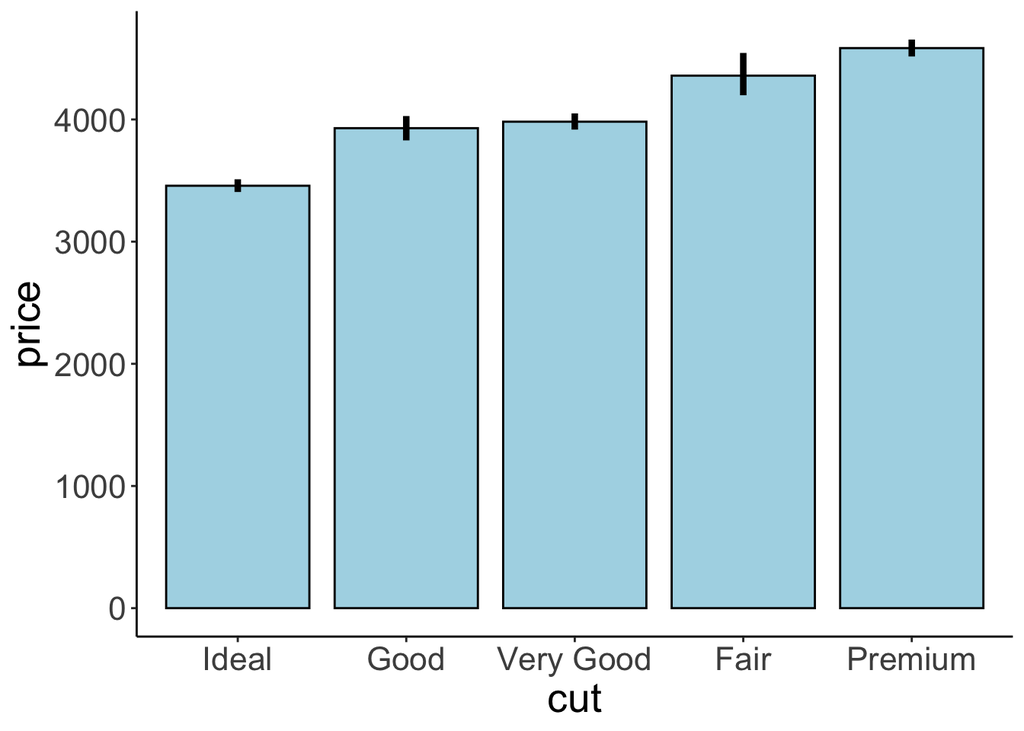

```r
ggplot(data = df.diamonds,
       mapping = aes(x = reorder(cut, price),
                     y = price)) +
       # mapping = aes(x = cut, y = price)) +
  stat_summary(fun = "mean",
               geom = "bar",
               color = "black",
               fill = "lightblue",
               width = 0.85) +
  stat_summary(fun.data = "mean_cl_boot",
               geom = "linerange",
               size = 1.5) +
  labs(x = "cut")
```

(Note the message `Warning: Using size aesthetic for lines was deprecated in ggplot2 3.4.0. Please use linewidth instead.`)

The `reorder()` function helps us to do just that. Now, the results are ordered according to price. To show the results in descending order, I would simply need to write `reorder(cut, -price)` instead.

### 3.4.3 Dealing with legends

Legends form an important part of many figures. However, it is often better to avoid legends if possible, and directly label the data. This way, the reader doesn’t have to look back and forth between the plot and the legend to understand what’s going on.

Here, we’ll look into a few aspects that come up quite often. There are two main functions to manipulate legends with ggplot2 1. `theme()` (there are a number of arguments starting with `legend.`) 2. `guide_legend()`

Let’s make a plot with a legend.

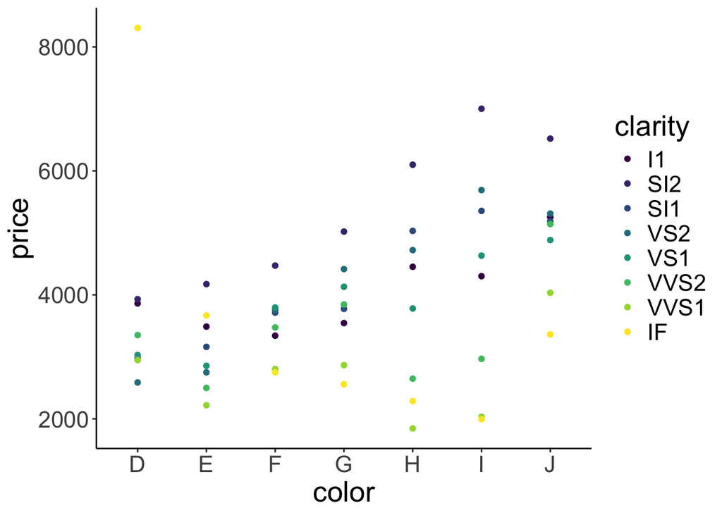

```r
ggplot(data = df.diamonds,
       mapping = aes(x = color,
                     y = price,
                     color = clarity)) +
  stat_summary(fun = "mean",
               geom = "point")
```

Let’s move the legend to the bottom of the plot:

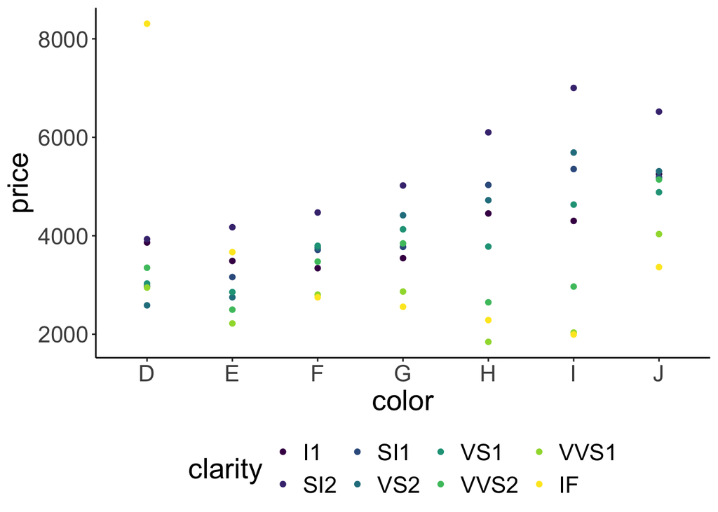

```r
ggplot(data = df.diamonds,
       mapping = aes(x = color,
                     y = price,
                     color = clarity)) +
  stat_summary(fun = "mean",
               geom = "point") +
  theme(legend.position = "bottom")
```

Let’s change a few more things in the legend using the `guides()` function:

- have 3 rows
- reverse the legend order
- make the points in the legend larger

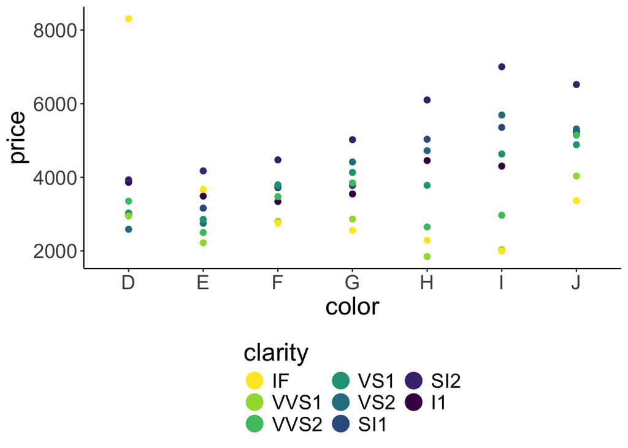

```r
ggplot(data = df.diamonds,
       mapping = aes(x = color,
                     y = price,
                     color = clarity)) +
  stat_summary(fun = "mean",
               geom = "point",
               size = 2) +
  theme(legend.position = "bottom",
        legend.direction = 'vertical') + # so legend title at top not side
  guides(color = guide_legend(nrow = 3, # 3 rows
                              reverse = TRUE, # reversed order
                              override.aes = list(size = 6))) # point size
```

### 3.4.4 Choosing good colors

[Color brewer](http://colorbrewer2.org/) helps with finding colors that are colorblind safe and printfriendly. For more information on how to use color effectively see [here](http://socviz.co/refineplots.html#refineplots).

viridis is very colorblind-safe as in `scale_fill_viridis_d` and `scale_color_viridis_d`. These are now a part of the `ggplot2` package.

You can also check plots with [CVSimulator](https://asada.website/cvsimulator/e/) (available for iphone, android, and on the web). I use this!

Another trick is to redundantly code, so that information conveyed with color is also conveyed via another dimension–like using *shape* of a data point as well as color. This example isn’t ideal (see the warning), but it should give you the idea:

```
Warning: Using shapes for an ordinal variable is not advised
```

```
Warning: Duplicated `override.aes` is ignored.
```

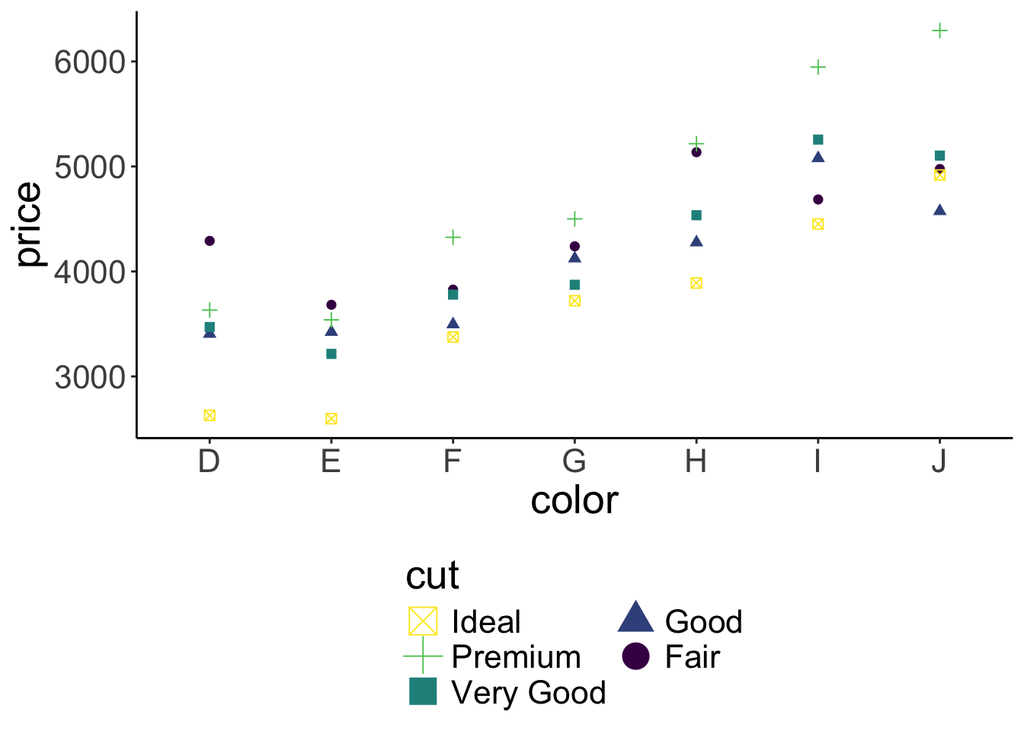

```r
ggplot(data = df.diamonds,
       mapping = aes(x = color,
                     y = price,
                     color = cut,
                     shape = cut)) +
  stat_summary(fun = "mean",
               geom = "point",
               size = 2) +
  theme(legend.position = "bottom",
        legend.direction = "vertical") +
  guides(color = guide_legend(nrow = 3, # 3 rows
                              reverse = TRUE, # reversed order
                              override.aes = list(size = 6)),
         shape = guide_legend(nrow=3, reverse=TRUE, override.aes=list(size=6)))
```

### 3.4.5 Customizing themes

For a given project, I often want all of my plots to share certain visual features such as the font type, font size, how the axes are displayed, etc. Instead of defining these for each individual plot, I can set a theme at the beginning of my project so that it applies to all the plots in this file. To do so, I use the `theme_set()` command:

```r
theme_set(theme_classic() + #classic theme
            theme(text = element_text(size = 20))) #text size
```

Here, I’ve just defined that I want to use `theme_classic()` for all my plots, and that the text size should be 20. For any individual plot, I can still overwrite any of these defaults.

## 3.5 Saving plots

To save plots, use the `ggsave()` command. Personally, I prefer to save my plots as pdf files. This way, the plot looks good no matter what size you need it to be. This means it’ll look good both in presentations as well as in a paper. You can save the plot in any format that you like.

I strongly recommend to use a relative path to specify where the figure should be saved. This way, if you are sharing the project with someone else via Stanford Box, Dropbox, or Github, they will be able to run the code without errors.

Here is an example for how to save one of the plots that we’ve created above.

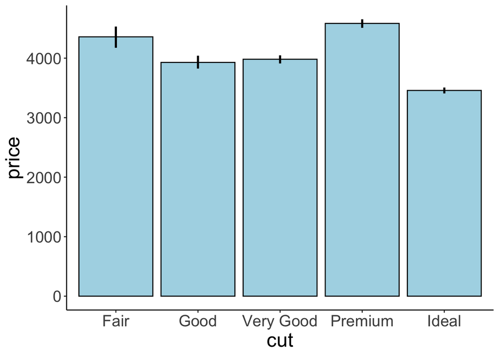

```r
p1 = ggplot(data = df.diamonds,
            mapping = aes(x = cut, y = price)) +
  stat_summary(fun = "mean",
               geom = "bar",
               color = "black",
               fill = "lightblue") +
  stat_summary(fun.data = "mean_cl_boot",
               geom = "linerange",
               size = 1)
print(p1)

p2 = ggplot(data = df.diamonds,
            mapping = aes(x = cut, y = price)) +
  stat_summary(fun = "mean",
               geom = "bar",
               color = "black",
               fill = "lightblue") +
  stat_summary(fun.data = "mean_cl_boot",
               geom = "linerange",
               size = 1)

ggsave(filename = "figures/diamond_plot.pdf",
       plot = p1,
       width = 8,
       height = 6)
```

Here, I’m saving the plot in the `figures` folder and it’s name is `diamond_plot.pdf`. I also specify the width and height as the plot in inches (which is the default unit).

## 3.6 Creating figure panels

Sometimes, we want to create a figure with several subfigures, each of which is labeled with a), b), etc. We have already learned how to make separate panels using `facet_wrap()` or `facet_grid()`. The R package `patchwork` makes it very easy to combine multiple plots. You can find out more about the package [here](https://patchwork.data-imaginist.com/articles/patchwork.html).

Let’s combine a few plots that we’ve made above into one.

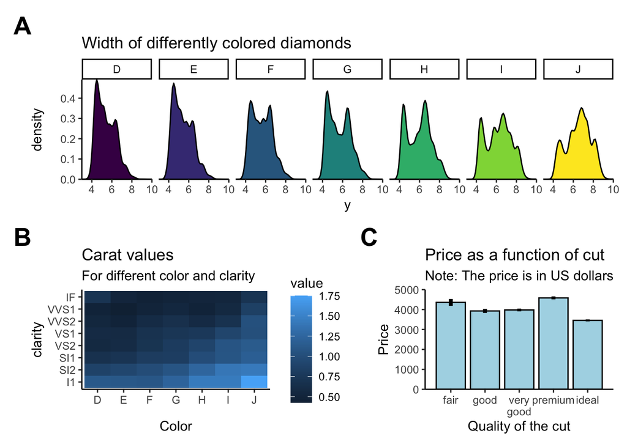

```r
# first plot
p1 = ggplot(data = df.diamonds,
            mapping = aes(x = y,
                          fill = color)) +
  geom_density(bw = 0.2,
               show.legend = F) +
  facet_grid(cols = vars(color)) +
  labs(title = "Width of differently colored diamonds") +
  coord_cartesian(xlim = c(3, 10),
                  expand = F) #setting expand to FALSE removes any padding on x and y axes

# second plot
p2 = ggplot(data = df.diamonds,
            mapping = aes(x = color,
                          y = clarity,
                          z = carat)) +
  stat_summary_2d(fun = "mean",
                  geom = "tile") +
  labs(title = "Carat values",
       subtitle = "For different color and clarity",
       x = "Color")

# third plot
p3 = ggplot(data = df.diamonds,
            mapping = aes(x = cut,
                          y = price)) +
  stat_summary(fun = "mean",
               geom = "bar",
               color = "black",
               fill = "lightblue",
               width = 0.85) +
  stat_summary(fun.data = "mean_cl_boot",
               geom = "linerange",
               size = 1.5) +
  scale_x_discrete(labels = c("fair", "good", "very\ngood", "premium", "ideal")) +
  labs(title = "Price as a function of cut",
       subtitle = "Note: The price is in US dollars",
       x = "Quality of the cut",
       y = "Price") +
  coord_cartesian(xlim = c(0.25, 5.75),
                  ylim = c(0, 5000),
                  expand = F)

# combine the plots
p1 + (p2 + p3) +
  plot_layout(ncol = 1) &
  plot_annotation(tag_levels = "A") &
  theme_classic() &
  theme(plot.tag = element_text(face = "bold", size = 20))

# ggsave("figures/combined_plot.png", width = 10, height = 6)
```

Not a perfect plot yet, but you get the idea. To combine the plots, we defined that we would like p2 and p3 to be displayed in the same row using the `()` syntax. And we specified that we only want one column via the `plot_layout()` function. We also applied the same `theme_classic()` to all the plots using the `&` operator, and formatted how the plot tags should be displayed. For more info on how to use `patchwork`, take a look at the [readme](https://github.com/thomasp85/patchwork) on the github page.

Other packages that provide additional functionality for combining multiple plots into one are

- [`gridExtra`](https://cran.r-project.org/web/packages/gridExtra/index.html) and
- [`cowplot`](https://cran.r-project.org/web/packages/cowplot/index.html). You can find more information on how to lay out multiple plots [here](https://cran.r-project.org/web/packages/egg/vignettes/Ecosystem.html).

An alternative way for making these plots is to use Adobe Illustrator, Powerpoint, or Keynote. However, you want to make changing plots as easy as possible. Adobe Illustrator has a feature that allows you to link to files. This way, if you change the plot, the plot within the illustrator file gets updated automatically as well.

If possible, it’s **much** better to do everything in R though so that your plot can easily be reproduced by someone else.

## 3.7 Peeking behind the scenes

Sometimes it can be helpful for debugging to take a look behind the scenes. Silently, `ggplot()` computes a data frame based on the information you pass to it. We can take a look at the data frame that’s underlying the plot.

```
[1] 56 18
```

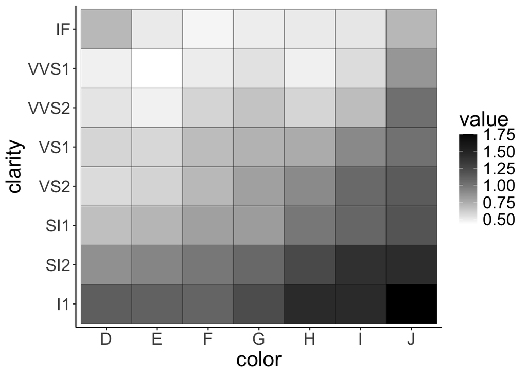

```r
p = ggplot(data = df.diamonds,
           mapping = aes(x = color,
                         y = clarity,
                         z = carat)) +
  stat_summary_2d(fun = "mean",
                  geom = "tile",
                  color = "black") +
  scale_fill_gradient(low = "white", high = "black")
print(p)

build = ggplot_build(p)
df.plot_info = build$data[[1]]
dim(df.plot_info) # data frame dimensions
```

If a plot looks weird, it’s worth taking a look behind the scenes. For example, something we thing we could have tried is the following (in fact, this is what I tried first):

```
[1] 53940    15
```

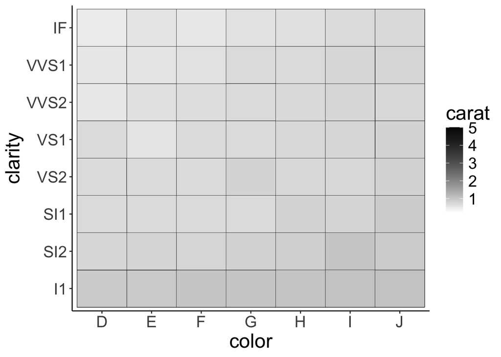

```r
p = ggplot(data = df.diamonds,
           mapping = aes(x = color,
                         y = clarity,
                         fill = carat)) +
  geom_tile(color = "black") +
  scale_fill_gradient(low = "white",
                      high = "black")
print(p)

build = ggplot_build(p)
df.plot_info = build$data[[1]]
dim(df.plot_info) # data frame dimensions
```

Why does this plot look different from the one before? What went wrong here? Notice that the data frame associated with the ggplot2 object has 53940 rows. So instead of plotting means here, we plotted all the individual data points. So what we are seeing here is just the top layer of many, many layers.